# STAT 6502 HW #3

Daniel Park

February 10, 2016

### 9.15, 9.17, 9.18, 9.22, 9.25, 9.26, 9.28, 9.34, 9.41, 9.53

### 9.15

Suppose that under $H_0$, a measurement $X$ is $N(0, \sigma^2)$, and that under $H_1$, $X$ is $N(1,\sigma^2)$ and the prior probability $P(H_0)=P(H_1)$. For $\sigma=1$ and $x \in [0,3]$, plot and compare (1) the $p$-value for the test of $H_0$ and (2) $P(H_0|x)$. Can the $p$-value be interpreted as the probability that $H_0$ is true? Choose another value of $\sigma$ and repeat.

**Solution**  
Normal Distribution $f(x)=\frac{1}{\sigma \sqrt{2 \pi}} \exp\bigg[\frac{-(x-\mu)^2}{2\sigma^2}\bigg]$ The likelihood ratio for a single random variable $X$ is: $\begin{aligned} T(X) &= \frac{f_0(X)}{f_1(X)} \\ &= \frac{\frac{1}{\sigma \sqrt{2 \pi}} \exp\Big[-\frac{(X-\mu_0)^2}{2\sigma^2}\Big]}{\frac{1}{\sigma \sqrt{2 \pi}} \exp\Big[-\frac{(X-\mu_1)^2}{2\sigma^2}\Big]} \\ &= \exp\bigg[-\frac{(X-\mu_0)^2}{2\sigma^2} + \frac{(X-\mu_1)^2}{2\sigma^2}\bigg] \\ &= \exp\bigg\{-\frac{1}{2\sigma^2}\Big[(X-\mu_0)^2 - (X-\mu_1)^2\Big]\bigg\} \\ &= \exp\bigg\{-\frac{1}{2\sigma^2}\Big[X^2-2X\mu_0+ \mu_0^2 - (X^2-2X\mu_1+ \mu_1^2)\Big]\bigg\} \\ &= \exp\bigg\{-\frac{1}{2\sigma^2}\Big[-2X\mu_0+ \mu_0^2 +2X\mu_1+ \mu_1^2\Big]\bigg\} \\ &= \exp\bigg\{-\frac{1}{2\sigma^2}\Big[2(\mu_1-\mu_0)X+ \mu_0^2 + \mu_1^2\Big]\bigg\} \end{aligned}$ Because $\mu_0 < \mu_1$, we can see that $T(X)$ is a monotonically decreasing function as $X$ increases. So instead of evaluating the likelihood ratio to judge the validity of $H_0$, we may do so by simply focusing on $X$ (note that all other values in the ratio are fixed). And we know that $X$ is a normally distributed random variable. How $X$ is distributed is the probability that $H_0$ is true - that is, $P(H_0|x)$.

To get a better sense of our likelihood ratio (though not necessary for this problem), we can plug in our parameters: $\begin{aligned} T(X) &= \exp\bigg\{-\frac{1}{2\cdot 1^2}\Big[2(1 - 0)X+ 0^2 + 1^2\Big]\bigg\} \\ &= \exp\bigg\{-\frac{2X+1}{2}\bigg\} \\ \end{aligned}$

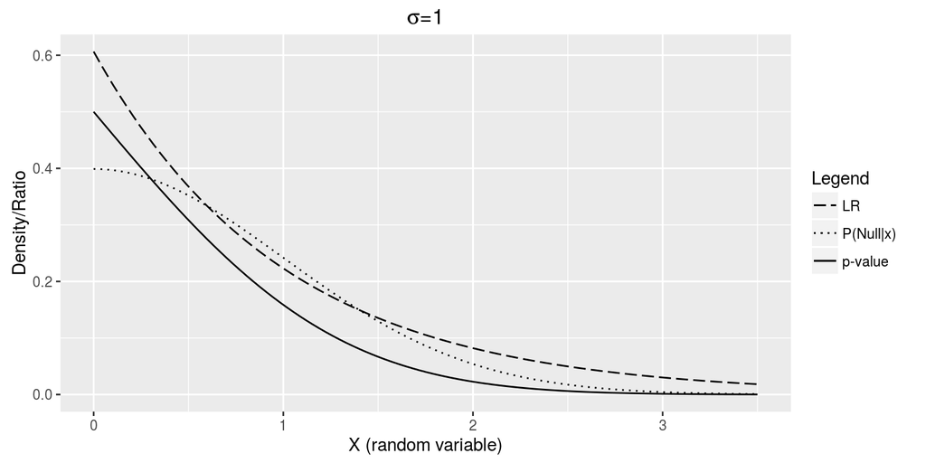

```r
library(ggplot2)

ggplot(data.frame(x = c(0, 3.5)), aes(x)) +
  stat_function(fun=function(x) dnorm(x=x, mean=0, sd=1), mapping=aes(linetype="P(Null|x)")) +
  stat_function(fun=function(x) exp(-x-.5), mapping=aes(linetype="LR")) +
  stat_function(fun=function(x) 1-pnorm(q=x, mean=0, sd=1), mapping=aes(linetype="p-value")) +
  labs(title=expression(paste(sigma, "=1")), y="Density/Ratio", x="X (random variable)") +
  scale_linetype_manual(name="Legend", values=c("longdash", "dotted", "solid"))
```

The $p$-value is not to be interpreted as the probability that $H_0$ is true. The $p$-value is calculated based on $H_0$. It is the calculated probability of observing another value equal to or more extreme than the current observation.

Next we set $\sigma$ to $0.5$:

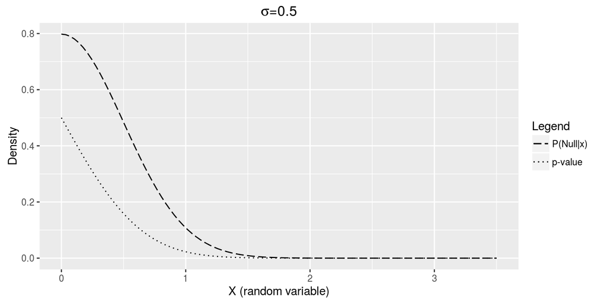

### 9.17

Let $X \sim N(0, \sigma^2)$, and consider testing $H_0: \sigma=\sigma_0$ versus $H_A: \sigma=\sigma_1$, where $\sigma_1 > \sigma_0$. The values $\sigma_0$ and $\sigma_1$ are fixed.

1. What is the likelihood ratio as a function of $x$? What values favor $H_0$? What is the rejection region of a level $\alpha$ test?
2. For a sample, $X_1,X_2\dots,X_n$ distributed as above, repeat the previous question.
3. Is the test in the previous question uniformly most powerful for testing $H_0:\sigma=\sigma_0$ versus $H_1:\sigma > \sigma_0$?

**Solution**

### 9.17.a

Normal Distribution $f(x)=\frac{1}{\sigma \sqrt{2 \pi}} \exp\bigg[\frac{-(x-\mu)^2}{2\sigma^2}\bigg]$ Likelihood ratio $\begin{aligned} T(X) &= \frac{P(X|H_0)}{P(X|H_1)} \\ &= \frac{f_0(X)}{f_1(X)} \\ &= \frac{\frac{1}{\sigma_0 \sqrt{2 \pi}} \exp\bigg(\frac{-X^2}{2\sigma_0^2}\bigg)}{\frac{1}{\sigma_1 \sqrt{2 \pi}} \exp\bigg(\frac{-X^2}{2\sigma_1^2}\bigg)} \\ &= \frac{\sigma_1}{\sigma_0}\exp\bigg(\frac{X^2}{2\sigma_1^2}-\frac{X^2}{2\sigma_0^2}\bigg) \\ &=\frac{\sigma_1}{\sigma_0}\exp\bigg(\frac{X^2}{2}\frac{\sigma_0^2 - \sigma_1^2}{\sigma_1^2\sigma_0^2}\bigg) \end{aligned}$ Given that $\sigma_1 > \sigma_0$, then $\sigma_0^2 - \sigma_1^2 < 0$ which means that $T(X)$ has an inverse relationship with $X$: $T(X)$ monotonically decreases as $X$ increases. Smaller values for $X$ favor $H_0$.

The rejection region $\alpha$ is the probability that, given that $H_0$ is true, the value $X^2$ is greater than a to-be-determined $k$ such that it is equal to $\alpha$: $P\big(X^2 > k \ \big| \ H_0: \sigma=\sigma_0\big) = \alpha$

It is worth noting that the square of a normally distributed random variable, $N(\mu, \sigma^2)$, follows a chi-square distribution with $df=1$.

### 9.17.b

$\begin{aligned} T(\mathbf{X}) &= \frac{P(X|H_0)}{P(X|H_1)} \\ &= \frac{f_0(\mathbf{X})}{f_1(\mathbf{X})} \\ &= \prod_{i=1}^n \frac{\frac{1}{\sigma_0 \sqrt{2 \pi}} \exp\bigg(\frac{-X_i^2}{2\sigma_0^2}\bigg)}{\frac{1}{\sigma_1 \sqrt{2 \pi}} \exp\bigg(\frac{-X_i^2}{2\sigma_1^2}\bigg)} \\ &=\bigg(\frac{\sigma_1}{\sigma_0}\bigg)^n\exp\bigg(\frac{\sigma_0^2 - \sigma_1^2}{2\sigma_1^2\sigma_0^2} \sum_{i=1}^n X_i^2\bigg) \end{aligned}$

Again, given that $\sigma_1 > \sigma_0$, $T(\mathbf{X})$ is a monotonically decreasing function of $\sum X_i^2$.

The sum of $n$ chi-square random variables with $df=1$ is a chi-square random variable with $df=n$.

Since large sums of $X^2$ would lead us to reject $H_0$, for a specified $\alpha$, we would reject $H_0$ when $\sum X_i^2$ exceeds a to-be-determined $k$ such that $P\bigg(\sum_{i=1}^n X_i^2 > k \ \Big| \ H_0: \sigma=\sigma_0\bigg) = \alpha$

### 9.17.c

$k$ represents the $(1-\alpha)^{th}$ quantile of a chi-square distribution. How $k$ is determined is not dependent on $\sigma_1$ (provided that $\sigma_1 > \sigma_0$). Therefore, it is uniformly most powerful.

### 9.18

Let $X_1, X_2, \dots, X_n$ be i.i.d. random variables from a double exponential distribution with density $f(x)=\frac{1}{2}\lambda\exp(-\lambda |x|)$. Derive a likelihood ratio test of the hypothesis $H_0: \lambda=\lambda_0$ versus $H_1:\lambda=\lambda_1$, where $\lambda_0$ and $\lambda_1>\lambda_0$ are specified numbers. Is the test uniformly most powerful against the alternative $H_1: \lambda > \lambda_0$?

**Solution**  
$\begin{aligned} T(\mathbf{X}) &= \frac{f_0(\mathbf{X})}{f_1(\mathbf{X})} \\ &= \prod_{i=1}^n \frac{\frac{1}{2}\lambda_0\exp(-\lambda_0 |X_i|)}{\frac{1}{2}\lambda_1\exp(-\lambda_1 |X_i|)} \\ &= \bigg(\frac{\lambda_0}{\lambda_1}\bigg)^n\exp\bigg((\lambda_1-\lambda_0)\sum_{i=1}^n |X_i|\bigg) \end{aligned}$

Given that $\lambda_1 > \lambda_0$, we conclude that $T(\mathbf{X})$ is a monotonically increasing function of $\sum |X_i|$, where $X_i$ follows a double-exponential distribution. Large sums favor the null hypothesis. Therefore, our likelihood ratio test will reject at level $\alpha$ where the following equation is satisfied $P\bigg(\sum_{i=1}^n \big|X_i\big| < k \ \Big| \ H_0: \lambda = \lambda_0 \bigg) = \alpha$ Because we can rely on a single $k$ value to form our test (our condition $\lambda_1 > \lambda_0$ ensures that $T(\mathbf{X})$ is always a monotonically increasing function of $\sum |X_i|$), we can designate our test as a uniformly most powerful test.

### 9.22

In Example A of Section 8.5.3 a confidence interval for the variance of a normal distribution was derived. Use Theorem B of Section 9.3 to derive an acceptance region for testing the hypothesis $H_0: \sigma^2=\sigma_0^2$ at the significance level $\alpha$ based on a sample $X_1,X_2,\dots,X_n$. Precisely describe the rejection region if $\sigma_0=1,n=15,\alpha=.05$.

**Solution**  
The theorem that is referenced states that a given confidence region includes the information on how to determine an acceptance region. That is, if we have have the confidence region $P[\theta_0 \in C(\mathbf{X}) \ | \ \theta=\theta_0] = 1 - \alpha$ then the acceptance region is $A(\theta_0) = \{\mathbf{X} \ | \ \theta_0 \in C(\mathbf{X})\}$

A confidence interval for $\hat{\sigma}$ is $P\bigg(\frac{n\hat{\sigma}^2}{\chi^2_{n-1,1 - \alpha/2}} \leq \sigma^2 \leq \frac{n\hat{\sigma}^2}{\chi^2_{n-1,\alpha/2}} \bigg) = 1 - \alpha$

If $\sigma_0=1,n=15,\alpha=.05$, then the lower bound is:  
$\frac{n\hat{\sigma}^2}{\chi^2_{n-1,1 - \alpha/2}} =$ `(15*1^2)/qchisq(p=1-.05/2, df=15-1)` = 0.5742957

and the upper bound:  
$\frac{n\hat{\sigma}^2}{\chi^2_{n-1,\alpha/2}} =$ `(15*1^2)/qchisq(p=.05/2, df=15-1)` = 2.6649014

So the rejection region includes values for $\hat{\sigma}^2$ that exceed $2.67$ or are below $0.57$.

### 9.25

Calculate the likelihood ratio for Example B of Section 9.5 and compare the results of a test based on the likelihood ratio to those of one based on Pearson’s chi-square statistic.

**Solution**  
We are interested in testing whether or not the individual bin counts are distributed in such a way that their probabilities obey a common parameter. In this case, our null hypothesis is that our cells are Poisson distributed with a parameter $\lambda$.

We are asked to use the Likelihood Ratio Test as our test statistic: $-2 \log \Lambda = 2 \sum_{i=1}^n Obs_i \cdot \log\bigg(\frac{Obs_i}{Exp_i}\bigg)$

Calculating the expected values requires knowing the densities of each bin which requires us to use an estimate of our parameter. We are given, $\hat{\lambda}=2.44$, which was derived using the standard mle of a Poisson distribution: $\overline{X}$. However, the bins for the larger counts have been merged, so we cannot rely on $\overline{X}$ as an accurate mle.

We can determine the mle using `R`:

```r
observed <- c(56, 104, 80, 62, 42, 27, 9, 20)
total <- sum(observed)
lik <- function(lambda) {
  sum1 <- dmultinom(x=observed, size=total, prob=c(dpois(x=0:6, lambda=lambda), 1-ppois(q=6, lambda=lambda)))
  return(sum1)
}
mle <- optimize(f=lik, interval=c(1, 3), maximum=TRUE)
mle$maximum
```

```
## [1] 2.386598
```

So `R`’s optimized $\hat{\lambda}$ is only slightly smaller than using the mle of $\lambda$ that the book uses.

Now we can use the Poisson pmf to determine the densities of each bin.

```r
# x is clearly defined for the first 7 bins, so we can calculate the densities
#  directly by entering x= 0, 1, 2, ..., 6
# The last bin doesn't have a specific number, so its density will be
#   determined by taking the complement of the first 7 bins' densities.
p_mle_R <- c(dpois(x=0:6, lambda=lambda.hat.R),
             1-dpois(x=6, lambda.hat.R))
expected_R <- p_mle_R*total
clump <- data.frame(num_per_sq=num_per_sq, p_obs=p_obs, p_mle_book=p_mle_book, p_mle_R=p_mle_R, observed=observed, expected_book=expected_book, expected_R=expected_R)
options(width=100)
clump
```

```
##   num_per_sq  p_obs p_mle_book    p_mle_R observed expected_book expected_R
## 1          0 0.1400    0.08725 0.09194193       56          34.9  36.776771
## 2          1 0.2600    0.21275 0.21942843      104          85.1  87.771372
## 3          2 0.2000    0.25950 0.26184374       80         103.8 104.737497
## 4          3 0.1550    0.21100 0.20830526       62          84.4  83.322105
## 5          4 0.1050    0.12875 0.12428524       42          51.5  49.714095
## 6          5 0.0675    0.06275 0.05932378       27          25.1  23.729513
## 7          6 0.0225    0.02550 0.02359700        9          10.2   9.438802
## 8         >6 0.0500    0.01250 0.97640300       20           5.0 390.561198
```

Again, the likelihood ratio statistic is $-2 \log \Lambda = 2 \sum_{i=1}^n Obs_i \cdot \log\bigg(\frac{Obs_i}{Exp_i}\bigg)$ Calculating the LR statistic:

```r
deviance.clump <- 2*sum(observed*log(observed/expected_R)) # LR test statistic
deviance.clump
```

```
## [1] -124.3007
```

Calculating $p$-value, where the degrees of freedom is equal to the number of groups minus one and minus the number of parameters estimated. Here, we estimated one parameter: $\lambda$. So $df=8-1-1=6$.

```r
bins <- 8
1- pchisq(q=deviance.clump, df=bins-1-1) # p-value
```

```
## [1] 1
```

### 9.26

True or false:

1. The generalized likelihood ratio statistic $\Lambda$ is always less than or equal to 1.  
   **True**. The generalized $\Lambda$ compares the maximum likelihood of the null hypothesis against the maximum likelihood of the entire sample space, which includes the null hypothesis.
2. If the $p$-value is $0.03$, the corresponding test will reject at the significance level $0.02$.  
   **False**. The $p$-value needs to be less than the significance level for the test to reject the null hypothesis. Even in a one-tailed test, a $p$-value of $0.03$ would fall within the acceptance region.
3. If a test rejects at significance level $0.06$, then the $p$-value is less than or equal to $0.06$  
   **True**. Assuming that this is a one-tailed test, a test rejects when the $p$-value is less than or equal to the significance level.
4. The $p$-value of a test is the probability that the null hypothesis is correct.  
   **False**. The $p$-value tells us the probability of obtaining another value that is equal to or more extreme than the one that has been observed. Furthermore, this probability is conditioned upon the assumption that the null hypothesis is true.
5. In testing a simple versus simple hypothesis via the likelihood ratio, the $p$-value equals the likelihood ratio.  
   **False**. The $p$-value is based on the distribution of the random variable in the likelihood ratio.
6. If a chi-square test statistic with 4 degrees of freedom has a value of 8.5, the $p$-value is less than $.05$.  
   **False**. `1-pchisq(q=8.5, df=4)` = 0.0748872

### 9.28

Suppose that a test statistic $T$ has a standard normal null distribution.

1. If the test rejects for large values of $|T|$, what is the $p$-value corresponding to $T=1.50$?  
   **Solution**  
   This test is two-tailed, meaning that our rejection region is $T \leq -1.50 \ \text{and} \ \ T \geq 1.50$ The p-value is `2*(1-pnorm(q=1.5))`=0.134
2. Answer the same question if the test rejects for large $T$.  
   **Solution**  
   This is a one-tailed test where our rejection region is $T \geq 1.50$ The p-value is `1-pnorm(q=1.5)`=0.067

### 9.34

Test the goodness of fit of the data to the genetic model given in Problem 55 of Chapter 8.

**8.55** For two factors - starchy or sugary, and green base leaf or white base leaf - the following counts for the progeny of self-fertilized heterozygotes were observed (Fisher 1958):

| Type | Count |
| --- | --- |
| Starchy green | 1997 |
| Starchy white | 906 |
| Sugary green | 904 |
| Sugary white | 32 |

According to genetic theory, the cell probabilities are $.25(2 + \theta), .25(1-\theta), .25(1-\theta),$ and $.25\theta$, where $\theta(0 < \theta < 1)$ is a parameter related to the linkage of the factors.

**Solution**  
Using last quarter’s homework assignment, the mle of the parameter is $\hat{\theta} = 0.0357$

```r
type <- c("strch_grn", "strch_wht", "sgry_grn", "sgry_wht")
count <- c(1997, 906, 904, 32)
theta.hat <- 0.0357
p <- c(.25*(2 + theta.hat), .25*(1-theta.hat), .25*(1-theta.hat), .25*theta.hat)
expected <- p*sum(count)
leaf <- data.frame(type=type, count=count, p=p, expected)
leaf
```

```
##        type count        p   expected
## 1 strch_grn  1997 0.508925 1953.76307
## 2 strch_wht   906 0.241075  925.48693
## 3  sgry_grn   904 0.241075  925.48693
## 4  sgry_wht    32 0.008925   34.26308
```

The Pearson chi-square statistic for a goodness of fit test is $\chi^2 = \sum_{i=1}^m \frac{[x_i - np_i(\hat{\theta})]^2}{np_i(\hat{\theta})} = \frac{(\text{Obs}_i - \text{Exp}_i)^2}{\text{Exp}_i^2}$ The numerator is the square of the difference between observed and expected, which is divided by the expected.

```r
(pearson.leaf <- sum(((leaf$count-leaf$expected)^2)/leaf$expected))
```

```
## [1] 2.015486
```

```r
1 - pchisq(q=pearson.leaf, df=2)
```

```
## [1] 0.365042
```

The likelihood ratio statistic is $-2 \log \Lambda = 2 \sum_{i=1}^n Obs_i \cdot \log\bigg(\frac{Obs_i}{Exp_i}\bigg)$ Calculating the LR statistic:

```r
deviance.leaf <- 2*sum(leaf$count*log(leaf$count/leaf$expected)) # LR test statistic
deviance.leaf
```

```
## [1] 2.018726
```

The degrees of freedom is the number of groups ($4$) minus one and minus the number of parameters estimated (i.e. $\theta$, or one parameter). So the p-value:

```r
1 - pchisq(q=deviance.leaf, df=2)
```

```
## [1] 0.3644511
```

### 9.41

Let $X_i \sim \text{bin}(n_i,p_i)$, for $i=1,\dots,m$, be independent. Derive a likelihood ratio test for the hypothesis $H_0: p_1=p_2=\cdots=p_m$ against the alternative hypothesis that the $p_i$ are not all equal. What is the large-sample distribution of the test statistic?

**Solution**  
Binomial pmf: $\binom{n}{x}p^{x}(1-p)^{n-x}$

Generalized likelihood ratio test: $\Lambda=\frac{\max_{\theta \in \Theta_0}L(\theta)}{\max_{\theta \in \Theta}L(\theta)}$ Let $p_0$ represent the probability for all $p_i$ for the null hypothesis. The mle, found on multiple occasions last quarter, is $\hat{p}_0 = \frac{\sum_{i=1}^m X_i}{\sum_{i=1}^m n_i}$ The book gives us the mle for $\hat{p}_i$ for an unrestricted sample space: $\hat{p}_i = \frac{X_i}{n_i}$

A likelihood ratio between $H_0$ and $H_1$ is $\frac{\prod_{i=1}^m \binom{n_i}{X_i}p_0^{X_i}(1-p_0)^{n_i-X_i}}{\prod_{i=1}^m \binom{n_i}{X_i}p_i^{X_i}(1-p_i)^{n_i-X_i}} = \frac{p_0^{\sum_{i=1}^m X_i}(1-p_0)^{\sum_{i=1}^m n_i-X_i}}{\prod_{i=1}^m p_i^{X_i}(1-p_i)^{n_i-X_i}}$

Re-arranging the mle’s so that $\sum X_i = \hat{p}_0 \sum n_i$ and $X_i = n_i \hat{p}_i$ we can make subsititutions to determine our LR test: $\begin{aligned} \Lambda &= \frac{\hat{p}_0^{\hat{p}_0 \sum n_i}(1-\hat{p}_0)^{(\sum_{i=1}^m n_i)-\hat{p}_0 \sum n_i}}{\prod_{i=1}^m \hat{p}_i^{n_i \hat{p}_i}(1-\hat{p}_i)^{n_i-n_i \hat{p}_i}} \\ &= \frac{\hat{p}_0^{\hat{p}_0 \sum n_i}(1-\hat{p}_0)^{\sum_{i=1}^m n_i(1- \hat{p}_0)}}{\prod_{i=1}^m \hat{p}_i^{n_i \hat{p}_i}(1-\hat{p}_i)^{n_i(1- \hat{p}_i)}} \end{aligned}$

### 9.53

Hoaglin (1980) suggested a “Poissonness plot” - a simple visual method for assessing goodness of fit. The expected frequencies for a sample of size $n$ from a Poisson distribution are $E_k=nP(X=k)=ne^{-\lambda}\frac{\lambda^k}{k!}$ or $\log E_k = \log n - \lambda + k \log \lambda - \log k!$ Thus, a plot of $\log(O_k) + \log k!$ versus $k$ should yield nearly a straight line with a slope of $\log \lambda$ and an intercept of $\log n - \lambda$. Construct such plots for the data of Problems 1, 2, and 3 of Chapter 8. Comment how straight they are.

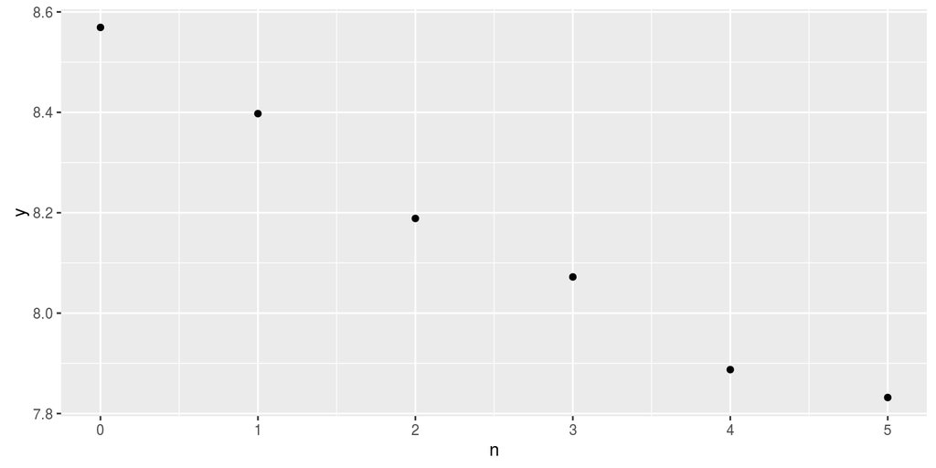

```r
n <- c(0:5)
obs <- c(5267, 4436, 1800, 534, 111, 21)
y <- c(log(obs)+log(factorial(n)))
berkson <- data.frame(n=n, y=y, obs=obs)
qplot(x=n, y=y, data=berkson)
```

Somewhat straight, though it levels off in the end.

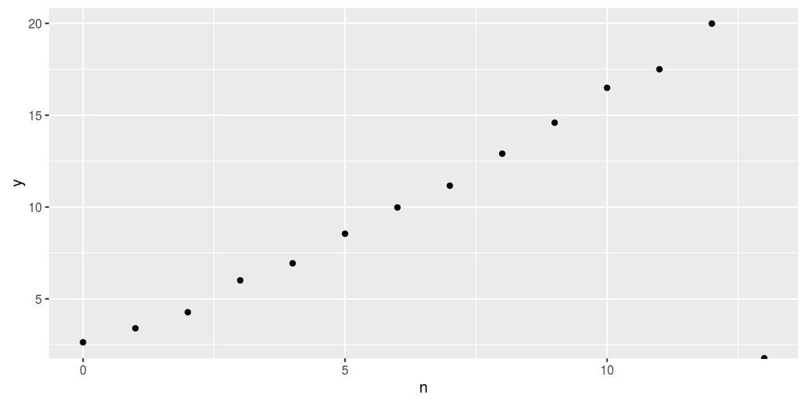

```r
n <- c(0:13)
freq <- c(14, 30, 36, 68, 43, 43, 30, 14, 10, 6, 4, 1, 1, 0)
y <- c(log(freq)+log(factorial(n)))
traffic <- data.frame(n=n, y=y, freq=freq)
qplot(x=n, y=y, data=traffic)
```

Fairly straight.

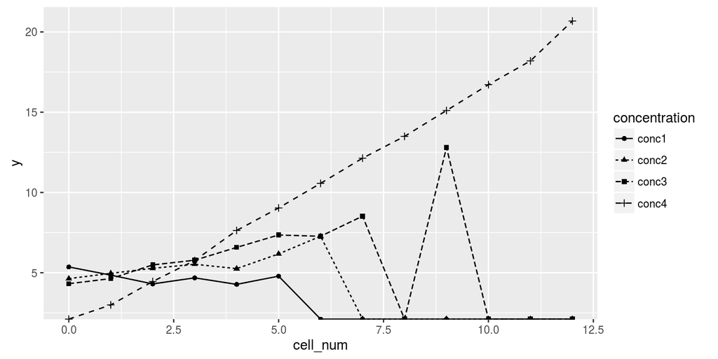

```r
cell_num <- c(0:12)
conc1 <- c(213, 128, 37, 18, 3, 1, 0, 0, 0, 0, 0, 0, 0)
conc2 <- c(103, 143, 98, 42, 8, 4, 2, 0, 0, 0, 0, 0, 0)
conc3 <- c(75, 103, 121, 54, 30, 13, 2, 1, 0, 1 ,0, 0, 0)
conc4 <- c(0, 20, 43, 53, 86, 70, 54, 37, 18, 10, 5, 2, 2)
yeast <- data.frame(cell_num=cell_num, conc1=conc1, conc2=conc2, conc3=conc3, conc4=conc4)
library(reshape2)
yeast.long <- melt(data=yeast, id="cell_num", variable.name="concentration", value.name="freq")
y <- c(log(yeast.long$freq)+log(factorial(yeast.long$cell_num)))
yeast.long$y <- y

ggplot(data=yeast.long, aes(x=cell_num, y=y, shape=concentration, linetype=concentration)) +
  geom_point() +
  geom_line()
```